# Computational Mathematics - Discussion 13

Mary Anna Kivenson

November 23, 2019

**Calculus Assignment 13**

## Question 1

Use integration by substition to solve the integral below.

$$\int 4e^{-7x}dx$$

Set the value to substitute: u = -7x

Find the value of dx: dx = -du/7

$$\frac{-4}{7}\int e^{u}du$$
$$\frac{-4}{7}e^{u} + c$$

## Question 2

Biologists are treating a pond contaminated with bacteria. The level of contamination is changing at a rate of dN/dt =  3150/t^4  220 bacteria per cubic centimeter per day, where t is the number of days since treatment began. Find a function N(t) to estimate the level of contamination if the level after 1 day was 6530 bacteria per cubic centimeter.

$$\frac{dN}{dt} = \frac{-3150}{t^4} - 220$$
$$N(t) = \frac{1050}{t^3} - 220t + c$$
$$6530 = 1050 - 220 + c$$
$$c = 5700$$

$$N(t) = \frac{1050}{t^3} - 220t + 5700$$

## Question 3

Midpoint rule:
$$M_n = \sum{f(m_i)\Delta x}$$

```r
f <- function(x) {
  return((2*x)-9)
}
delta_x = 1
area = delta_x*(f(5) + f(6) + f(7) + f(8))
print("Area of rectangles")
```

```
## [1] "Area of rectangles"
```

```r
print(area)
```

```
## [1] 16
```

## Question 4

Find the area of the region bounded by the graphs of the given equations.

y = x^2  2x  2, y = x + 2 Enter your answer below.

$$\int_{-1}^{4} (x+2) - (x^2  2x  2) dx$$

$$\int_{-1}^{4} x^2 + 3x + 4 dx$$

$$[\frac{x^3}{3} + \frac{3x^2}{2} + 4x]_{-1}^{4}$$

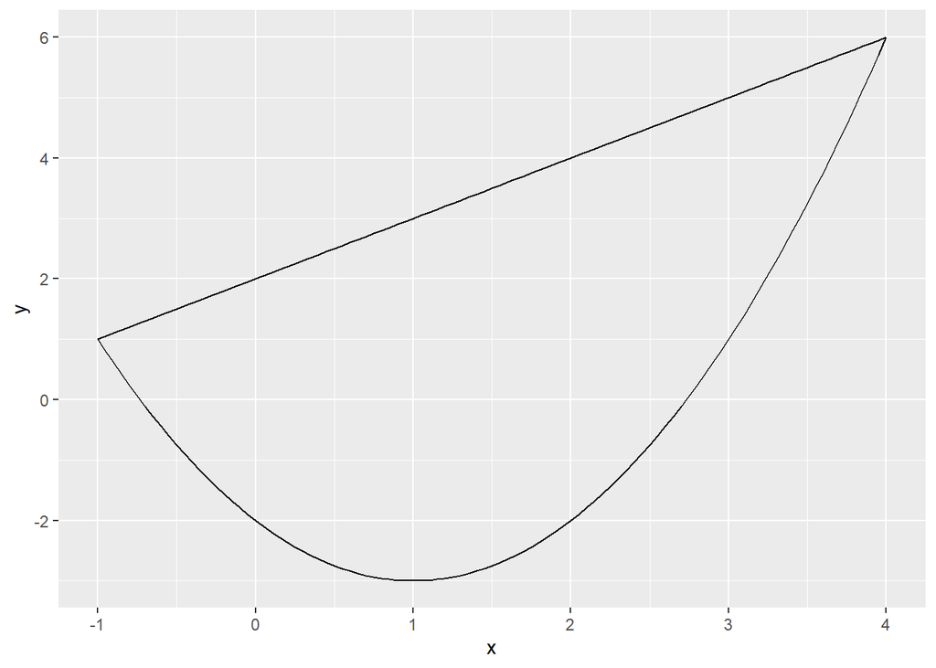

```r
y_1 <- function(x) {
  return((x^2)-2*x-2)
}

y_2 <- function(x) {
  return(x+2)
}

ggplot(data = data.frame(x = 0), mapping = aes(x = x)) +
  stat_function(fun = y_1) +
  stat_function(fun = y_2) + xlim(-1,4)
```

```r
y_int <- function(x) {
  return(((x^3)/3) + 3*(x^2)/2 + 4*x)
}

print("Area of the region bounded by the graphs:")
```

```
## [1] "Area of the region bounded by the graphs:"
```

```r
print(y_int(4)-y_int(-1))
```

```
## [1] 64.16667
```

## Question 5

A beauty supply store expects to sell 110 flat irons during the next year. It costs $3.75 to store one flat iron for one year. There is a fixed cost of $8.25 for each order. Find the lot size and the number of orders per year that will minimize inventory costs.

Storage cost:
$$sc = 3.75 * \frac{x}{2}$$

Ordering cost:
$$oc = 8.25 * \frac{110}{x}$$

Total cost:
$$tc = 1.875x + \frac{907.5}{x}$$

Derivative:
$$\frac{dtc}{dx} = 1.875- \frac{907.5}{x^2}$$
$$\frac{907.5}{1.875} = x^2$$

$$x = 22$$

110 / 22 = 5 orders

## Question 6

Use integration by parts to solve the integral below.
$$\int ln(9x) * x^6 dx$$

$$u = ln(9x) | dv = x^6dx$$

$$du = \frac{1}{x} dx | v = \frac{x^7}{7}$$

$$\int u dv = uv - \int vdu$$

$$\int ln(9x) x^6dx = ln(9x) * \frac{x^7}{7} - \int \frac{x^7}{7} \frac{1}{x}dx$$

$$\int ln(9x) * x^6 dx = \frac{x^7ln(9x)}{7} - \frac{1}{7}\int x^6 dx$$

$$\int ln(9x) * x^6 dx = \frac{x^7ln(9x)}{7} - \frac{x^7}{49} + c$$
$$\int ln(9x) * x^6 dx = \frac{x^7(7ln(9x) - 1)}{49} + c$$

## Question 7

Determine whether f(x) is a probability density function on the interval [1, e^6]. If not, determine the value of the definite integral.

f(x) = 1/6x

$$\int_{1}^{e^6} {\frac{1}{6x}}$$
$$\frac{1}{6}[ln(x)]_{1}^{e^6}$$

$$\frac{1}{6}[ln(e^6)-ln(1)]$$

$$\frac{1}{6}[6 - 0] = 1$$

f(x) is the probability density function on this interval since it is equal to 1.

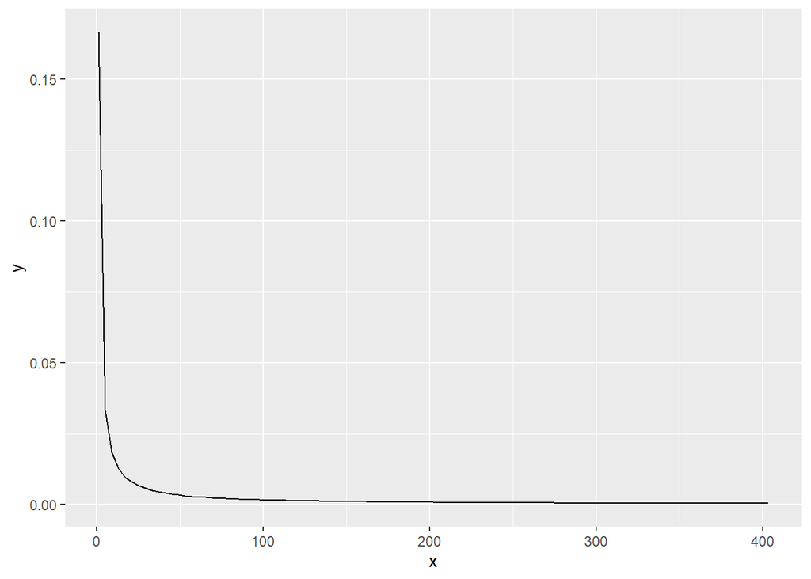

```r
pdf <- function(x) {
  return(1/(6*x))
}

ggplot(data = data.frame(x = 0), mapping = aes(x = x)) +
  stat_function(fun = pdf) + xlim(1, exp(6))
```